# 作业1-简介

# 2. 开始使用Jupyter Notebook和pandas package

在本课程中，我们将使用pandas 数据结构和数据分析工具。

因此，请从云班课的Class1中阅读pandas教程，并回答关于数据集abalone(鲍鱼)的相关问题。

abalone数据集包含在本次作业的附件中。 变量的简短描述是：

- Sex M (male), F (female), and I (infant)
- Length Longest shell measurement (mm)
- Diameter perpendicular to length (mm)
- Height with meat in shell (mm)
- Weight whole abalone (grams)
- Rings determining the actual age of an abalone is a bit like estimating the age of a tree. Rings are formed in the shell of the abalone as it grows, usually at the rate of one ring per year.
- 性别M（雄），F（雌）和I（幼体）
- 长度 最长外壳尺寸（毫米）
- 直径 垂直于长度的直径（毫米）
- 高度 带壳肉的高度（毫米）
- 重量 整只鲍鱼的重量（克）
- 环 确定鲍鱼的实际年龄，有点像估计一棵树的年龄。 随着鲍鱼的生长，在鲍鱼壳中形成环，通常以每年一环的速度形成。

首先，让我们将pandas包作为pd导入，并将数据从CSV文件读取到pandas DataFrame中。

```python
import pandas as pd
data = pd.read_csv("abalone.csv")
```

问题0是您应如何回答以下问题的示例。

首先，在#TODO单元中，您必须编写代表解决方案的代码。

然后在答案单元格中用您自己的语言写下答案。

**0. 数据的内存是多少？** (例子)

```python
# TODO - 在这里您必须编写代码。
data.memory_usage(deep=True).sum()
```

```
102128
```

**a. 数据集的列名是什么？**

```python
# TODO
#data.columns
data.describe()
```

|  | Length | Diameter | Height | Weight | Rings |
| --- | --- | --- | --- | --- | --- |
| count | 1000.000000 | 1000.000000 | 1000.000000 | 1000.000000 | 1000.000000 |
| mean | 0.522760 | 0.405955 | 0.141100 | 0.825540 | 11.318000 |
| std | 0.120064 | 0.098832 | 0.057064 | 0.490380 | 47.227697 |
| min | 0.075000 | 0.055000 | 0.000000 | 0.002000 | 1.000000 |
| 25% | 0.450000 | 0.345000 | 0.115000 | 0.438875 | 8.000000 |
| 50% | 0.545000 | 0.420000 | 0.145000 | 0.801000 | 9.000000 |
| 75% | 0.615000 | 0.480000 | 0.165000 | 1.146250 | 11.000000 |
| max | 0.815000 | 0.650000 | 1.130000 | 2.555000 | 1500.000000 |

**答案:**

```python
data.loc[data.Rings==1500,'Rings']=15
data.describe()
```

|  | Length | Diameter | Height | Weight | Rings |
| --- | --- | --- | --- | --- | --- |
| count | 1000.000000 | 1000.000000 | 1000.000000 | 1000.000000 | 1000.000000 |
| mean | 0.522760 | 0.405955 | 0.141100 | 0.825540 | 9.833000 |
| std | 0.120064 | 0.098832 | 0.057064 | 0.490380 | 3.141493 |
| min | 0.075000 | 0.055000 | 0.000000 | 0.002000 | 1.000000 |
| 25% | 0.450000 | 0.345000 | 0.115000 | 0.438875 | 8.000000 |
| 50% | 0.545000 | 0.420000 | 0.145000 | 0.801000 | 9.000000 |
| 75% | 0.615000 | 0.480000 | 0.165000 | 1.146250 | 11.000000 |
| max | 0.815000 | 0.650000 | 1.130000 | 2.555000 | 27.000000 |

**b. 此数据框中有多少个观测值（即行）？**

```python
# TODO
data.shape
```

```
(1000, 6)
```

**答案:**

**c. 打印数据集中的前4行。 打印的观测值的特征“环”"Rings"的值是多少？**

```python
# TODO
data.head(4)
```

|  | Gender | Length | Diameter | Height | Weight | Rings |
| --- | --- | --- | --- | --- | --- | --- |
| 0 | F | 0.505 | 0.385 | 0.135 | 0.6185 | 12 |
| 1 | F | 0.650 | 0.475 | 0.165 | 1.3875 | 9 |
| 2 | I | 0.520 | 0.380 | 0.135 | 0.5395 | 8 |
| 3 | F | 0.550 | 0.425 | 0.140 | 0.9520 | 7 |

```python
data.head(4)['Rings']
```

```
0    12
1     9
2     8
3     7
Name: Rings, dtype: int64
```

**答案:**

**d. 提取数据帧的最后3行。 这些鲍鱼的“重量”"Weight"是多少？**

```python
# TODO
data.tail(3)
```

|  | Gender | Length | Diameter | Height | Weight | Rings |
| --- | --- | --- | --- | --- | --- | --- |
| 997 | M | 0.660 | 0.500 | 0.165 | 1.3195 | 9 |
| 998 | I | 0.525 | 0.400 | 0.130 | 0.6455 | 8 |
| 999 | M | 0.515 | 0.395 | 0.135 | 1.0070 | 8 |

```python
data.tail(3)['Weight']
```

```
997    1.3195
998    0.6455
999    1.0070
Name: Weight, dtype: float64
```

**答案:**

**e. 第577行的直径值是多少？**

```python
# TODO
data.loc[577]['Diameter']
```

```
0.455
```

**答案:** 第577行的直径值是0.455。

**f. 高度 一列的平均值是什么？**  
提示1：使用pandas describe（）方法

```python
# TODO
data.describe() #data.mean()['Height']
```

|  | Length | Diameter | Height | Weight | Rings |
| --- | --- | --- | --- | --- | --- |
| count | 1000.000000 | 1000.000000 | 1000.000000 | 1000.000000 | 1000.000000 |
| mean | 0.522760 | 0.405955 | 0.141100 | 0.825540 | 9.833000 |
| std | 0.120064 | 0.098832 | 0.057064 | 0.490380 | 3.141493 |
| min | 0.075000 | 0.055000 | 0.000000 | 0.002000 | 1.000000 |
| 25% | 0.450000 | 0.345000 | 0.115000 | 0.438875 | 8.000000 |
| 50% | 0.545000 | 0.420000 | 0.145000 | 0.801000 | 9.000000 |
| 75% | 0.615000 | 0.480000 | 0.165000 | 1.146250 | 11.000000 |
| max | 0.815000 | 0.650000 | 1.130000 | 2.555000 | 27.000000 |

**答案:**

**g. 提取 gender 为M并且 weight 值低于0.75的数据框的行子集。 此子集中 diameter 的平均值是多少？**

```python
# TODO
subset=data[(data['Gender']=='M')&(data['Weight']<0.75)]
subset
```

|  | Gender | Length | Diameter | Height | Weight | Rings |
| --- | --- | --- | --- | --- | --- | --- |
| 11 | M | 0.400 | 0.310 | 0.110 | 0.3140 | 11 |
| 12 | M | 0.460 | 0.360 | 0.125 | 0.5470 | 8 |
| 16 | M | 0.540 | 0.420 | 0.155 | 0.7385 | 12 |
| 18 | M | 0.345 | 0.255 | 0.090 | 0.2005 | 9 |
| 22 | M | 0.465 | 0.360 | 0.110 | 0.4955 | 7 |
| ... | ... | ... | ... | ... | ... | ... |
| 904 | M | 0.505 | 0.385 | 0.105 | 0.5525 | 9 |
| 942 | M | 0.495 | 0.385 | 0.135 | 0.7090 | 12 |
| 962 | M | 0.360 | 0.295 | 0.130 | 0.2765 | 10 |
| 979 | M | 0.490 | 0.385 | 0.125 | 0.6090 | 8 |
| 992 | M | 0.480 | 0.365 | 0.130 | 0.5305 | 8 |

119 rows × 6 columns

```python
subset.mean()['Diameter']
```

```
0.3426470588235295
```

**答案:**

**h. 年龄等于18的鲍鱼的最小长度是多少？**

```python
# TODO
data_ring_18=data[data['Rings']==18]
data_ring_18.min()['Length']
```

```
0.465
```

**答案:**

**i. 鲍鱼的体重与它们有多少个环有关吗？ 请提供结论的证据和解释性文字？**  
提示1：使用groupby和mean()

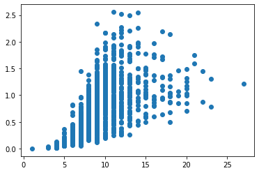

```python
# 解决方案1
import matplotlib.pyplot as plt
%matplotlib inline
plt.scatter(data['Rings'],data['Weight'])
```

```python
# 解决方案2
data.corr()
```

|  | Length | Diameter | Height | Weight | Rings |
| --- | --- | --- | --- | --- | --- |
| Length | 1.000000 | 0.987479 | 0.598616 | 0.920861 | 0.555995 |
| Diameter | 0.987479 | 1.000000 | 0.602035 | 0.923661 | 0.575281 |
| Height | 0.598616 | 0.602035 | 1.000000 | 0.585369 | 0.388355 |
| Weight | 0.920861 | 0.923661 | 0.585369 | 1.000000 | 0.532438 |
| Rings | 0.555995 | 0.575281 | 0.388355 | 0.532438 | 1.000000 |

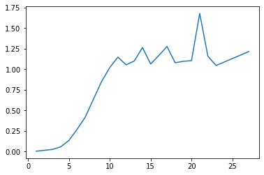

```python
#方案3
data_mean=data.groupby('Rings').mean()
plt.plot(data_mean['Weight'])
```

```python
#方案4
import scipy.stats as stats
#输出结果第一个值为pearsonr相关系数，
#第二个为p-value，所以这里Rings列和Weight值是显著相关的
stats.pearsonr(data['Rings'],data['Weight'])
```

```
(0.5324378852898222, 2.696380769250152e-74)
```

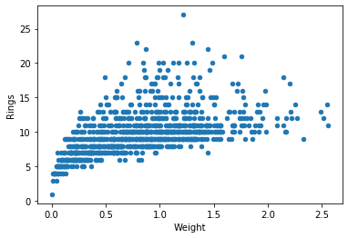

```python
#方案5 周悦方案
import matplotlib.pyplot as plt
%matplotlib inline
data.plot(x='Weight',y='Rings',kind="scatter")
```

```
协方差: 0.8202334969969972
相关系数: 0.5324378852898225
-----我是分界线-------
```

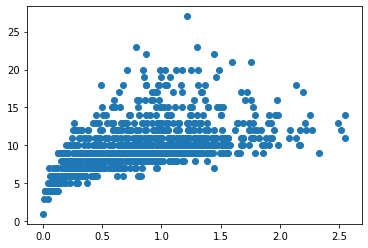

```python
#所有的Rings和Weight
#通过数据观测，存在异常数据，过滤
df_Select = data.loc[data['Rings'] < 100]
#环与体重的协方差
df_Select_cov = df_Select['Rings'].cov(df_Select['Weight'])
#环与体重的相关系数
df_Select_corr = df_Select['Rings'].corr(df_Select['Weight'])
print("协方差:",df_Select_cov)
print("相关系数:",df_Select_corr)
print("-----我是分界线-------")
#画散点图
Y = df_Select.loc[:,'Rings']
X = df_Select.loc[:,'Weight']
plt.scatter(X,Y)
plt.show()
```

```
协方差: 0.8202334969969972
相关系数: 0.5324378852898225
-----我是分界线-------
```

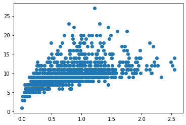

```python
#通过数据观测，存在异常数据，过滤
#所有的Rings和Weight
#通过数据观测，存在异常数据，过滤
df_Select = data.loc[data['Rings'] < 100]
#环与体重的协方差
df_Select_cov = df_Select['Rings'].cov(df_Select['Weight'])
#环与体重的相关系数
df_Select_corr = df_Select['Rings'].corr(df_Select['Weight'])
print("协方差:",df_Select_cov)
print("相关系数:",df_Select_corr)
print("-----我是分界线-------")
#画散点图
Y = df_Select.loc[:,'Rings']
X = df_Select.loc[:,'Weight']
plt.scatter(X,Y)
plt.show()
```

```
协方差: 2.81795510268804
相关系数: 0.8364053448590969
-----虽然我也不知道我在写什么，但我是分界线-------
```

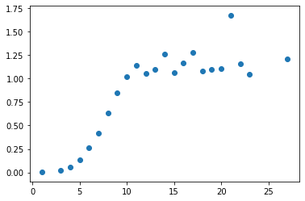

```python
#通过数据观测，存在异常数据，过滤
data1 = data.loc[data['Rings'] < 100]
#按照Rings分类，取各组Weight平均值
data_RM = data1.groupby(['Rings'],as_index=False)['Weight'].mean()
#环与体重的协方差
data_RM_cov = data_RM['Rings'].cov(data_RM['Weight'])
#环与体重的相关系数
data_RM_corr = data_RM['Rings'].corr(data_RM['Weight'])
print("协方差:",data_RM_cov)
print("相关系数:",data_RM_corr)
print("-----虽然我也不知道我在写什么，但我是分界线-------")
#画散点图
X = data_RM.loc[:,'Rings']
Y = data_RM.loc[:,'Weight']
plt.scatter(X,Y)
plt.show()
```

```
协方差: 0.8229286399254755
相关系数: 0.5496914116612127
-----虽然我也不知道我在写什么，但我是分界线-------
```

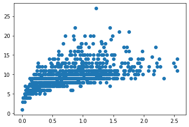

```python
#通过数据观测，存在异常数据，过滤
data2 = data.loc[data['Rings'] < 100]
#按照Weight分类，取各组Rings平均值
data_MR = data2.groupby(['Weight'],as_index=False)['Rings'].mean()
#环与体重的协方差
data_MR_cov = data_MR['Rings'].cov(data_MR['Weight'])
#环与体重的相关系数
data_MR_corr = data_MR['Rings'].corr(data_MR['Weight'])
print("协方差:",data_MR_cov)
print("相关系数:",data_MR_corr)
print("-----虽然我也不知道我在写什么，但我是分界线-------")
Y = data_MR.loc[:,'Rings']
X = data_MR.loc[:,'Weight']
plt.scatter(X,Y)
plt.show()
```

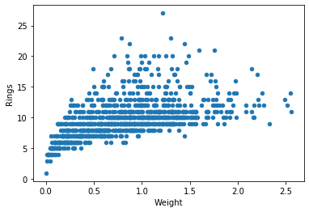

```python
#方案6 郝晓雅方案
# TODO

W_column = ['Rings']
R_column = ['Weight']

w = data[W_column]
r = data[R_column]

x = w.values
y = r.values
data.plot(x='Weight',y='Rings',kind="scatter")
```

```
[0.00304987]
[[0.08468732]]
```

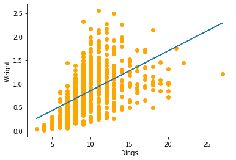

```python
from sklearn.model_selection import train_test_split

x_train, x_test, y_train, y_test = train_test_split(x, y,test_size = 1/4, random_state=0)
from sklearn.linear_model import LinearRegression

model = LinearRegression()
model.fit(x_train, y_train)

print(model.intercept_)
print(model.coef_)
y_pred = model.predict(x_test)
import matplotlib.pyplot as plt

plt.scatter(x_train, y_train,color = 'orange')
plt.plot(x_train, model.predict(x_train))
plt.xlabel('Rings')
plt.ylabel('Weight')

plt.show()
```

**答案:**

在提交作业并检查结果之前，请先在Jupyter Notebook中使用 **"Cell->Run All"** 命令。 请注意，我们将在评分前再次运行所有单元格。